# Exam 1

## Exam 1

#### Metainformation

1. | Tag | Value |
   | --- | --- |
   | `file` | Assumptions_uu-assumptions-202-en_uu-assumptions-202-en |
   | `name` | uu-assumptions-202-en |
   | `section` | Assumptions |
   | `type` | schoice |
   | `solution` | FALSE, FALSE, TRUE, FALSE |
   | `ID` | 8ced4 |
   | `Type` | Interpreting output |
   | `Program` | SPSS |
   | `Language` | English |
   | `Level` | Statistical Literacy |

#### Question

   To assess the assumptions for a regression analysis the table below is used.

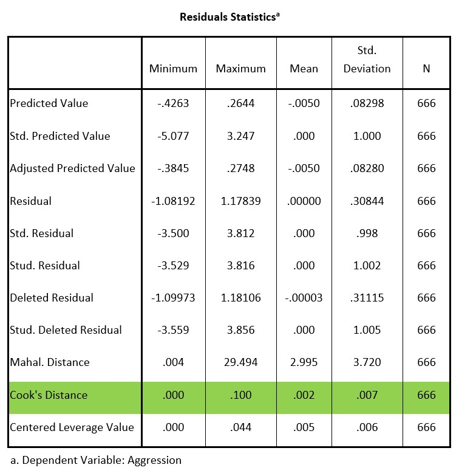

   1. **FALSE:** The presence of outliers in the Y-space has been checked and the condition is not met. In other words, the analysis may not be carried out.
   2. **FALSE:** The presence of outliers in the X-space has been checked and the condition has been met. In other words, the analysis may be carried out.
   3. **TRUE:** The presence of outliers in the XY-space has been checked and the condition is met. In other words, the analysis may be carried out.
   4. **FALSE:** The presence of multicollinearity has been checked and the condition is not met. In other words, the analysis may not be carried out.

#### Solution

   Cook’s distance is used to determine whether there are outliers in XY-space. The rule of thumb is that values below 1 do not indicate outliers. The maximum value of Cook’s distance in this analysis is .100. This is lower than 1, so the assumption is met.